# Vectors

## Types of Vectors

In this chapter, I would learn about the type of vectors. There are basically 4 types of vectors. That is logical (TRUE- FALSE), Integer (non decimal values, NaN and Inf, -Inf), Double (decimal values) and Character.

Vector that is the same type of elements is Atomic Vector. Otherwise it is a list.

```r
lgl_var <- c(TRUE, FALSE)
int_var <- c(1L, 6L, 10L)
dbl_var <- c(1, 2.5, 4.5)
chr_var <- c("these are", "some strings")
```

To get the type of the vector, we would use the function typeof()

```r
typeof(lgl_var)
```

```
[1] "logical"
```

```r
typeof(int_var)
```

```
[1] "integer"
```

```r
typeof(dbl_var)
```

```
[1] "double"
```

```r
typeof(chr_var)
```

```
[1] "character"
```

## Missing values

Calculation with NA are mostly NA. Excepting some cases

```r
NA + 10
```

```
[1] NA
```

```r
NA *10
```

```
[1] NA
```

```r
NA < 10
```

```
[1] NA
```

```r
!NA
```

```
[1] NA
```

NA is something between TRUE and FALSE. Let’s see it. When doing with TRUE and FALSE, | returns in TRUE & returns in FALSE. NA is in between.

```r
NA| TRUE
```

```
[1] TRUE
```

```r
NA & TRUE
```

```
[1] NA
```

```r
NA | FALSE
```

```
[1] NA
```

```r
NA & FALSE
```

```
[1] FALSE
```

```r
NA ^ 0
```

```
[1] 1
```

Checking if NA equal NA or other numbers. Returns all in NA.

```r
x <- c(NA, 1, NA, 2)
x == NA
```

```
[1] NA NA NA NA
```

## Testing and Coercion

We can use the function is.*() to test the type of a vector. But it applies to is.logical(), is.integer(), is.double() and is.character()

```r
is.logical(lgl_var)
```

```
[1] TRUE
```

```r
is.integer(lgl_var)
```

```
[1] FALSE
```

```r
is.double(dbl_var)
```

```
[1] TRUE
```

```r
is.character(chr_var)
```

```
[1] TRUE
```

Check carefully if you use these tests below by reading their documentation:

```r
is.vector(lgl_var)
```

```
[1] TRUE
```

```r
is.numeric(chr_var)
```

```
[1] FALSE
```

```r
is.atomic(dbl_var)
```

```
[1] TRUE
```

When combining different type of vector into one vector, the type of the vector will be corerced into this order: character > double > integer > logical.

```r
typeof(c(lgl_var, dbl_var))
```

```
[1] "double"
```

```r
typeof(c(lgl_var, chr_var))
```

```
[1] "character"
```

```r
typeof(c(chr_var, int_var))
```

```
[1] "character"
```

Coercing into integer will make the element that is character becomes NA

```r
mixed_var <- c(chr_var, int_var)
typeof(mixed_var)
```

```
[1] "character"
```

```r
as.integer(mixed_var)
```

```
NAs introduced by coercion
```

```
[1] NA NA  1  6 10
```

## Attributes

We can set name pair attributes for any variable. Attribute can be strings or numeric.

```r
a <- 1:3
attr(a, "x") <- "abcdef"
attr(a, "x")
```

```
[1] "abcdef"
```

```r
attr(a, "y") <- 4:6
str(attributes(a))
```

```
List of 2
 $ x: chr "abcdef"
 $ y: int [1:3] 4 5 6
```

```r
# Or equivalently:
a <- structure(1:3, x = "abcdef", y = 4:6)
str(attributes(a))
```

```
List of 2
 $ x: chr "abcdef"
 $ y: int [1:3] 4 5 6
```

There are 2 attributes that is generally preserved. It is names (character vector giving each elements a name) and dim (short for dimension, used to turn vectors into matrices or arrays).

## Names

We have a few way to creates name

```r
# Create name at the beginning
x <- c("a" = 1, "b" = 2, "c" = 3)
x
```

```
a b c
1 2 3
```

```r
# Create a names vector
y = 1:3
names(y) = c("a", "b", "c")
y
```

```
a b c
1 2 3
```

```r
# Inline with setNames()
z <- setNames(1:3, c("a", "b", "c"))
z
```

```
a b c
1 2 3
```

## Dimensions

```r
# setting matrix
x <- matrix(1:6, nrow = 2, ncol = 3)
x
```

```
     [,1] [,2] [,3]
[1,]    1    3    5
[2,]    2    4    6
```

```r
y <- array(1:12, c(2, 3, 2))
y
```

```
, , 1

     [,1] [,2] [,3]
[1,]    1    3    5
[2,]    2    4    6

, , 2

     [,1] [,2] [,3]
[1,]    7    9   11
[2,]    8   10   12
```

We can also modify the dim to set the object

```r
z <- 1:6
dim(z) <- c(2, 3)
z
```

```
     [,1] [,2] [,3]
[1,]    1    3    5
[2,]    2    4    6
```

Vector, Matrix and Array have the functions as below.

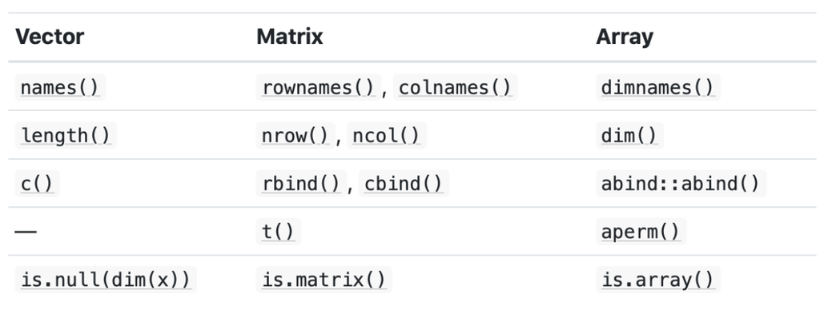

Formula

A vector without a dim attribute is often thought as 1 dimension, but actually NULL dimension. We can also have matrix with one row or one column (row or column vector) with single dimension. We can reveal the difference in str() function

```r
str(c(1:3))
```

```
 int [1:3] 1 2 3
```

```r
str(matrix(1:3, ncol = 1))
```

```
 int [1:3, 1] 1 2 3
```

```r
str(matrix(1:3, nrow = 1))
```

```
 int [1, 1:3] 1 2 3
```

```r
str(array(1:3, 3))
```

```
 int [1:3(1d)] 1 2 3
```

Now I will view the source code of setNames and unname. I will use the function getAnywhere() to view that

```r
getAnywhere(setNames)
```

```
A single object matching ‘setNames’ was found
It was found in the following places
  package:stats
  namespace:stats
  namespace:methods
with value

function (object = nm, nm)
{
    names(object) <- nm
    object
}
<bytecode: 0x7fea3c8dfd98>
<environment: namespace:stats>
```

They simply use the function names() to set the name of the object

```r
getAnywhere(unname)
```

```
A single object matching ‘unname’ was found
It was found in the following places
  package:base
  namespace:base
with value

function (obj, force = FALSE)
{
    if (!is.null(names(obj)))
        names(obj) <- NULL
    if (!is.null(dimnames(obj)) && (force || !is.data.frame(obj)))
        dimnames(obj) <- NULL
    obj
}
<bytecode: 0x7fea39dc6130>
<environment: namespace:base>
```

dim when applied to one dimensional vector will return NULL. nrow and ncol will applied for matrix.

### What is the difference between these objects below?

```r
x1 <- array(1:5, c(1, 1, 5))
x2 <- array(1:5, c(1, 5, 1))
x3 <- array(1:5, c(5, 1, 1))
```

x1 is the array of 5. x2 is the array of 1 with the matrix 1 * 5 x3 is the array of 1 with the matrix 5 * 1

### Why we don’t see the comment attribute of the object when we print?

```r
structure(1:5, comment = "my attribute")
```

```
[1] 1 2 3 4 5
```

```
#> [1] 1 2 3 4 5
```

Usually dim and names are shown when printing out the attribute/ structure.

## S3 atomic vectors

### Factor

Factor is under the integer vector but has 2 attributes: class is factor and levels.

```r
x <- factor(c("a", "b", "b", "a"))
typeof(x)
```

```
[1] "integer"
```

```r
attributes(x)
```

```
$levels
[1] "a" "b"

$class
[1] "factor"
```

Another example of factor. Factor would make us know about other levels even it is not appeared in the observations.

```r
sex_char <- c("m", "m", "m")
sex_factor <- factor(sex_char, levels = c("m", "f"))

table(sex_char)
```

```
sex_char
m
3
```

```r
table(sex_factor)
```

```
sex_factor
m f
3 0
```

Order is a small variation of of factors. It might have meaning such as low, medium and high.

```r
# Order
grade <- ordered(c("b", "b", "c", "a"), levels = c("c", "b", "a"))
grade
```

```
[1] b b c a
Levels: c < b < a
```

```r
today <- Sys.Date()
typeof(today)
```

```
[1] "double"
```

```r
attributes(today)
```

```
$class
[1] "Date"
```

### Datetimes

2 type of datetime information POSIXct and POSIXlt: ct stands for calendar time and lt stands for local time. I will focus on the POSIXct

```r
now_ct <- as.POSIXct("2021-06-28 22:00", tz = "UTC")
typeof(now_ct)
```

```
[1] "double"
```

```r
attributes(now_ct)
```

```
$class
[1] "POSIXct" "POSIXt"

$tzone
[1] "UTC"
```

### Difftime

```r
one_week_1 <- as.difftime(1, unit = "weeks")
one_week_1
```

```
Time difference of 1 weeks
```

### Exercise

#### 1. What sort of object the table return? What attributes does it have? How does the dimensionality change when you tabulate more variables?

```r
f1 <- factor(letters)
levels(f1) <- rev(levels(f1))
```

This function reverses the level of the f1 object.

#### 3. What is the differences between f1, f2 and f3

```r
f2 <- rev(factor(letters))

f3 <- factor(letters, levels = rev(letters))
```

## List

List element are technically the same type and each element is a reference to another object, which can be any type. Because of referencing, the list size might be much smaller than we think it might be.

```r
lobstr::obj_size(mtcars)
```

```
7,208 B
```

```r
l2 <- list(mtcars, mtcars, mtcars)
obj_size(l2)
```

```
7,288 B
```

### Testing and coercion

We can test the list by using is.list(). coerce using as.list() and see type by using typeof()

```r
typeof(l3)
```

```
[1] "list"
```

```r
is.list(l3)
```

```
[1] TRUE
```

```r
as.list(1:3)
```

```
[[1]]
[1] 1

[[2]]
[1] 2

[[3]]
[1] 3
```

### Matrices and arrays

list can be list matrix and list array by setting the attribute to them:

```r
l <- list(1:3, "a", TRUE, 1.0)
dim(l) <- c(2, 2)
l
```

```
     [,1]      [,2]
[1,] Integer,3 TRUE
[2,] "a"       1
```

```r
l[[1, 1]]
```

```
[1] 1 2 3
```

```
#> [1] 1 2 3
```

Using unlist

```r
typeof(unlist(l))
```

```
[1] "character"
```

Using as.vector()

```r
typeof(as.vector(l))
```

```
[1] "list"
```

## Dataframe and tibbles

Example of dataframe

```r
df1 <- data.frame(x = 1:3, y = letters[1:3])
typeof(df1)
```

```
[1] "list"
```

```r
attributes(df1)
```

```
$names
[1] "x" "y"

$class
[1] "data.frame"

$row.names
[1] 1 2 3
```

As we can see, dataframe is a list. Actually, dataframe is a named list of vectors. The attributes are names and row.names, class is data.frame. length of dataframe is the number of of columns.

Example of tibble

```r
library(tibble)
df2 <- tibble(x = 1:3, y = letters[1:3])
typeof(df2)
```

```
[1] "list"
```

```r
attributes(df2)
```

```
$names
[1] "x" "y"

$row.names
[1] 1 2 3

$class
[1] "tbl_df"     "tbl"        "data.frame"
```

```r
df <- data.frame(
  x = 1:3,
  y = c("a", "b", "c")
)

str(df)
```

```
'data.frame':   3 obs. of  2 variables:
 $ x: int  1 2 3
 $ y: Factor w/ 3 levels "a","b","c": 1 2 3
```

```r
df_str <- data.frame(x = 1:3, y = c("a", "b", "c"), stringsAsFactors = FALSE)
str(df_str)
```

```
'data.frame':   3 obs. of  2 variables:
 $ x: int  1 2 3
 $ y: chr  "a" "b" "c"
```

Tibble is lazy because they never coerce their input. Let see the identical example with function tibble

```r
df_str2 <- tibble(x = 1:3, y = c("a", "b", "c"))
str(df_str2)
```

```
Classes ‘tbl_df’, ‘tbl’ and 'data.frame':   3 obs. of  2 variables:
 $ x: int  1 2 3
 $ y: chr  "a" "b" "c"
```

We can see that tibble do not convert them automatically str to factor.

```r
names(data.frame('1' = 1))
```

```
[1] "X1"
```

```r
names(tibble('1' = 1))
```

```
[1] "1"
```

Tibbe as we see do not change the name of non-syntactic names unless we use check.names = FALSE, they don’t change name surrounded by ’’. Tibble allows you to refer to variable created during construction

```r
x <- tibble(x = 1:3, y = x*2)
x
```

| x | y |
| --- | --- |
| 1 | 2 |
| 2 | 4 |
| 3 | 6 |